# 2020 Road to The Kentucky Derby Horse Stats

Brenden Latham

1/16/2021

# 2020 Horse Racing

#### For Intro to Probability and Statistics by Dr. Nicholas Jacobs

The 2020 horse racing season was overshadowed by the recent pandemic, and as a result I didn’t get to follow it as closely as I would have liked. I am taking this opportunity to use that to my advantage and look back at the season while also learning about statistics. My data comes from [www.bloodhorse.com](https://www.bloodhorse.com/horse-racing/triple-crown/road-to-the-kentucky-derby/2020) and I received it from Dr. Jacobs. It is available on my github account name [BrendenLatham](https://github.com/BrendenLatham/horse-stats). It will also be shown below.

```r
df
```

```
##    Ranking              Horse Points Non.Restricted..Stakes.Earnings.
## 1        1        Tiz the Law    372                      $2,572,400
## 2        2          Authentic    200                      $2,840,000
## 3        3      Art Collector    150                        $476,461
## 4        4        Honor A. P.    140                        $490,000
## 5        5         Ny Traffic    110                        $472,820
## 6        6     King Guillermo     90                        $317,050
## 7        7     Thousand Words     83                        $297,000
## 8        8            Dr Post     80                        $340,035
## 9        9         Max Player     60                        $427,500
## 10      10           Caracaro     60                        $205,000
## 11      11    Country Grammer     50                        $106,400
## 12      12          Pneumatic     45                        $169,250
## 13      13        Enforceable     43                        $314,550
## 14      14     Swiss Skydiver     40                      $1,141,820
```

[output cut: 109 more lines]

## Project Part 1

### Data Overview

My data is relatively clean, but for the sake of simplification I will not be focusing much on Non-Restricted Steaks Earnings or Owner except maybe to later calculate the earnings of each owner. I will also be working with the values of Career Earnings in a way that they need to be in double format. I will call this simplified format dfs

```r
dfs <- data.frame(df) %>%
  select(Ranking,Horse,Points,Career.Earnings.,Trainer,Breeder)
dfs$Career.Earnings. <- as.numeric(gsub('[$,]', '',df$Career.Earnings.))
```

This is what that looks like

```r
dfs
```

```
##    Ranking              Horse Points Career.Earnings.            Trainer
## 1        1        Tiz the Law    372          2615300       Barclay Tagg
## 2        2          Authentic    200          2871200        Bob Baffert
## 3        3      Art Collector    150           664380          Joe Sharp
## 4        4        Honor A. P.    140           532200     John Shirreffs
## 5        5         Ny Traffic    110           565470 Saffie Joseph, Jr.
## 6        6     King Guillermo     90           340350  Juan Carlos Avila
## 7        7     Thousand Words     83           327000        Bob Baffert
## 8        8            Dr Post     80           370635      Todd Pletcher
## 9        9         Max Player     60           463500         Linda Rice
## 10      10           Caracaro     60           238800    Gustavo Delgado
## 11      11    Country Grammer     50           157320         Chad Brown
## 12      12          Pneumatic     45           256850    Steven Asmussen
## 13      13        Enforceable     43           397150         Mark Casse
## 14      14     Swiss Skydiver     40          1192980       Kenny McPeek
```

[output cut: 47 more lines]

I might want to look at the Individual Trainers as well. We can see that some trainers trained more than one horse on our data frame. Let me give you a look at each trainer and the horses they trained.

```r
hpt <- aggregate(Horse~Trainer,dfs,toString)
hpt
```

```
##               Trainer                                           Horse
## 1        Barclay Tagg                                     Tiz the Law
## 2       Blaine Wright                                     Anneau d'Or
## 3         Bob Baffert Authentic, Thousand Words, Uncle Chuck, Cezanne
## 4          Chad Brown                                 Country Grammer
## 5         Dale Romans                                 Attachment Rate
## 6      Dallas Stewart                              Winning Impression
## 7       Gregory Foley                                       Major Fed
## 8     Gustavo Delgado                                        Caracaro
## 9    Jeremiah O'Dwyer                                         Shotski
## 10          Joe Sharp                                   Art Collector
## 11        John Servis                                      Super John
## 12     John Shirreffs                                     Honor A. P.
## 13  Juan Carlos Avila                                  King Guillermo
## 14       Kenny McPeek                                  Swiss Skydiver
## 15         Linda Rice                                      Max Player
## 16         Mark Casse                                     Enforceable
## 17   Patrick Biancone                                    Sole Volante
## 18       Peter Eurton                                 Storm the Court
## 19        Ralph Nicks                                        Shivaree
## 20      Rey Hernandez                              Finnick the Fierce
## 21 Saffie Joseph, Jr.                                      Ny Traffic
## 22      Stanley Hough                       South Bend, Necker Island
## 23    Steven Asmussen                          Pneumatic, Rowdy Yates
## 24      Todd Pletcher                           Dr Post, Candy Tycoon
```

I find it interesting that Bob Baffert alone trained 4 of our 30 horses. This makes him responsible for roughly 13% of our horses. I wonder what the total earnings of his horses are. Lets make a table that shows this for all Trainers

```r
trainerval <- aggregate(Career.Earnings.~Trainer,dfs,sum)
trainerval
```

```
##               Trainer Career.Earnings.
## 1        Barclay Tagg          2615300
## 2       Blaine Wright           453821
## 3         Bob Baffert          3411200
## 4          Chad Brown           157320
## 5         Dale Romans           143732
## 6      Dallas Stewart            98552
## 7       Gregory Foley           215600
## 8     Gustavo Delgado           238800
## 9    Jeremiah O'Dwyer           236222
## 10          Joe Sharp           664380
## 11        John Servis            72560
## 12     John Shirreffs           532200
## 13  Juan Carlos Avila           340350
## 14       Kenny McPeek          1192980
## 15         Linda Rice           463500
## 16         Mark Casse           397150
## 17   Patrick Biancone           323310
## 18       Peter Eurton          1310451
## 19        Ralph Nicks           370505
## 20      Rey Hernandez           191290
## 21 Saffie Joseph, Jr.           565470
## 22      Stanley Hough           589844
## 23    Steven Asmussen           603406
## 24      Todd Pletcher           540485
```

and that adds to a total horse earning sum of

```r
totalhorseearnings <- sum(dfs$Career.Earnings.)
totalhorseearnings
```

```
## [1] 15728428
```

Split among our total horses

```r
horses <- dfs$Horse
length(horses)
```

```
## [1] 30
```

trained by a unique trainer count of

```r
trainers <- trainerval$Trainer
length(trainers)
```

```
## [1] 24
```

With Bob Baffert alone being responsible for 13% of our horses…

```r
baffertval <- trainerval[3,]
100/totalhorseearnings*baffertval$Career.Earnings.
```

```
## [1] 21.68812
```

and about 22% of our total money made. Almost 3.5 Million dollars! That’s a lot of cash! I would like to further look at this later in the project.

I find it very interesting how one man trained 4 horses and was responsible for such a large percentage of the total winnings. You can probably infer by now which horses won the highest paying races.

I think by now we have a solid grasp on our data and can see every variable’s relation to the others and how they interact.

### A bit more about our variables

We have gone over the Horse, Trainer, and Career Earnings variables. We also should take a quick look into our discrete Ranking and Points Variables, along with a nominal variable, Breeder.

+Ranking is the horses pre-Kentucky Derby season rank based on points.

+Points are awarded to the first 4 finishers in each of the 35 races leading up to the Kentucky derby. The top 20 scoring horses earn a spot in the Derby.

+Breeder is the name of the farm/stable/company that bred the horse.

Below is a visual summary of our variables.

```r
summary(dfs)
```

```
##     Ranking         Horse               Points      Career.Earnings.
##  Min.   : 1.00   Length:30          Min.   :  2.0   Min.   :  63000
##  1st Qu.: 8.25   Class :character   1st Qu.: 20.0   1st Qu.: 193400
##  Median :15.50   Mode  :character   Median : 39.0   Median : 333675
##  Mean   :15.50                      Mean   : 62.8   Mean   : 524281
##  3rd Qu.:22.75                      3rd Qu.: 75.0   3rd Qu.: 461080
##  Max.   :30.00                      Max.   :372.0   Max.   :2871200
##    Trainer            Breeder
##  Length:30          Length:30
##  Class :character   Class :character
##  Mode  :character   Mode  :character
##
##
##
```

## Project Part 2

### Categorical Variables

Now It’s time to look at some of my categorical variables. I will create a frequency table that allows us to look at all the trainers like we have Bob Baffert.

First I’ll look at the frequency for each.

```r
trainer_freq <- count(dfs, 'Trainer')
trainer_freq
```

```
##               Trainer freq
## 1        Barclay Tagg    1
## 2       Blaine Wright    1
## 3         Bob Baffert    4
## 4          Chad Brown    1
## 5         Dale Romans    1
## 6      Dallas Stewart    1
## 7       Gregory Foley    1
## 8     Gustavo Delgado    1
## 9    Jeremiah O'Dwyer    1
## 10          Joe Sharp    1
## 11        John Servis    1
## 12     John Shirreffs    1
## 13  Juan Carlos Avila    1
## 14       Kenny McPeek    1
## 15         Linda Rice    1
## 16         Mark Casse    1
## 17   Patrick Biancone    1
## 18       Peter Eurton    1
## 19        Ralph Nicks    1
## 20      Rey Hernandez    1
## 21 Saffie Joseph, Jr.    1
## 22      Stanley Hough    2
## 23    Steven Asmussen    2
## 24      Todd Pletcher    2
```

Now I’ll do relative frequency.

```r
trainer_relfreq <- trainer_freq
### freq needs to be a double
trainer_relfreq$freq <- as.double(trainer_relfreq$freq)
trainer_relfreq$freq <- trainer_relfreq$freq/length(df$Trainer)
trainer_relfreq <- rename(trainer_relfreq, c("freq"="relative_freq"))
trainer_relfreq
```

```
##               Trainer relative_freq
## 1        Barclay Tagg    0.03333333
## 2       Blaine Wright    0.03333333
## 3         Bob Baffert    0.13333333
## 4          Chad Brown    0.03333333
## 5         Dale Romans    0.03333333
## 6      Dallas Stewart    0.03333333
## 7       Gregory Foley    0.03333333
## 8     Gustavo Delgado    0.03333333
## 9    Jeremiah O'Dwyer    0.03333333
## 10          Joe Sharp    0.03333333
## 11        John Servis    0.03333333
## 12     John Shirreffs    0.03333333
## 13  Juan Carlos Avila    0.03333333
## 14       Kenny McPeek    0.03333333
## 15         Linda Rice    0.03333333
## 16         Mark Casse    0.03333333
## 17   Patrick Biancone    0.03333333
## 18       Peter Eurton    0.03333333
## 19        Ralph Nicks    0.03333333
## 20      Rey Hernandez    0.03333333
## 21 Saffie Joseph, Jr.    0.03333333
## 22      Stanley Hough    0.06666667
## 23    Steven Asmussen    0.06666667
## 24      Todd Pletcher    0.06666667
```

Lets combine these two tables

```r
trainer_freqs <- merge(trainer_freq, trainer_relfreq, by="Trainer")
trainer_freqs
```

```
##               Trainer freq relative_freq
## 1        Barclay Tagg    1    0.03333333
## 2       Blaine Wright    1    0.03333333
## 3         Bob Baffert    4    0.13333333
## 4          Chad Brown    1    0.03333333
## 5         Dale Romans    1    0.03333333
## 6      Dallas Stewart    1    0.03333333
## 7       Gregory Foley    1    0.03333333
## 8     Gustavo Delgado    1    0.03333333
## 9    Jeremiah O'Dwyer    1    0.03333333
## 10          Joe Sharp    1    0.03333333
## 11        John Servis    1    0.03333333
## 12     John Shirreffs    1    0.03333333
## 13  Juan Carlos Avila    1    0.03333333
## 14       Kenny McPeek    1    0.03333333
## 15         Linda Rice    1    0.03333333
## 16         Mark Casse    1    0.03333333
## 17   Patrick Biancone    1    0.03333333
## 18       Peter Eurton    1    0.03333333
## 19        Ralph Nicks    1    0.03333333
## 20      Rey Hernandez    1    0.03333333
## 21 Saffie Joseph, Jr.    1    0.03333333
## 22      Stanley Hough    2    0.06666667
## 23    Steven Asmussen    2    0.06666667
## 24      Todd Pletcher    2    0.06666667
```

So we can see that only 4 Trainers had more than 1 horse in the top 30 pre-Kentucky derby horses I find it interesting that Bob Baffert trained about 3 more top 30 horses than the average trainer in our data

Now lets look at the breeders in the same way.

```r
breeder_freq <- count(dfs, 'Breeder')
breeder_freq
```

```
##                                                           Breeder freq
## 1                                                    Brian Culnan    1
## 2  Carhue Investments with Grouseridge Ltd. & Marengo Investments    1
## 3                                                  Clearsky Farms    1
## 4                                                 Cloyce C. Clark    1
## 5                                        Flaxman Holdings Limited    1
## 6                         Fred W. Hertrich III & John D. Fielding    1
## 7                                                George Krikorian    1
## 8                                                   Hardacre Farm    1
## 9                                                 Highclere, Inc.    1
## 10                                              Highland Yard LLC    1
## 11   Hill 'n' Dale Equine Holdings, Inc. & St. Elias Stables, LLC    1
## 12                                      Jacks or Better Farm Inc.    1
## 13                                               Jerry Romans Jr.    1
## 14                                                  K & G Stables    1
## 15                                          Lloyd Madison IV, LLC    1
## 16                                Mr. & Mrs. C. Oliver Iselin III    1
## 17                                  Paige Jillian Blu Sky Stables    1
## 18                               Peter E. Blum Thoroughbreds, LLC    1
## 19                                   Scott Pierce & Debbie Pierce    1
## 20                                              SF Bloodstock LLC    1
## 21                         Springland Farm & Prime Bloodstock LLC    1
## 22                                            Stepping Stone Farm    1
## 23                          Stonestreet Thoroughbred Holdings LLC    2
## 24                                            Tracy Rene Strachan    1
## 25                                               Twin Creeks Farm    1
## 26                                              W. Bruce Lunsford    1
## 27                                         Winchell Thoroughbreds    1
## 28                                                   WinStar Farm    2
```

```r
breeder_relfreq <- breeder_freq
### freq needs to be a double
breeder_relfreq$freq <- as.double(breeder_relfreq$freq)
breeder_relfreq$freq <- breeder_relfreq$freq/length(df$Breeder)
rename(breeder_relfreq, c("freq"="relative_freq"))
```

```
##                                                           Breeder relative_freq
## 1                                                    Brian Culnan    0.03333333
## 2  Carhue Investments with Grouseridge Ltd. & Marengo Investments    0.03333333
## 3                                                  Clearsky Farms    0.03333333
## 4                                                 Cloyce C. Clark    0.03333333
## 5                                        Flaxman Holdings Limited    0.03333333
## 6                         Fred W. Hertrich III & John D. Fielding    0.03333333
## 7                                                George Krikorian    0.03333333
## 8                                                   Hardacre Farm    0.03333333
## 9                                                 Highclere, Inc.    0.03333333
## 10                                              Highland Yard LLC    0.03333333
## 11   Hill 'n' Dale Equine Holdings, Inc. & St. Elias Stables, LLC    0.03333333
## 12                                      Jacks or Better Farm Inc.    0.03333333
## 13                                               Jerry Romans Jr.    0.03333333
## 14                                                  K & G Stables    0.03333333
## 15                                          Lloyd Madison IV, LLC    0.03333333
## 16                                Mr. & Mrs. C. Oliver Iselin III    0.03333333
## 17                                  Paige Jillian Blu Sky Stables    0.03333333
## 18                               Peter E. Blum Thoroughbreds, LLC    0.03333333
## 19                                   Scott Pierce & Debbie Pierce    0.03333333
## 20                                              SF Bloodstock LLC    0.03333333
## 21                         Springland Farm & Prime Bloodstock LLC    0.03333333
## 22                                            Stepping Stone Farm    0.03333333
## 23                          Stonestreet Thoroughbred Holdings LLC    0.06666667
## 24                                            Tracy Rene Strachan    0.03333333
## 25                                               Twin Creeks Farm    0.03333333
## 26                                              W. Bruce Lunsford    0.03333333
## 27                                         Winchell Thoroughbreds    0.03333333
## 28                                                   WinStar Farm    0.06666667
```

```r
breeder_freqs <- merge(breeder_freq, breeder_relfreq, by="Breeder")
breeder_freqs <- rename(breeder_freqs, c("freq.x"="freq", "freq.y"="relative_freq"))
breeder_freqs
```

```
##                                                           Breeder freq
## 1                                                    Brian Culnan    1
## 2  Carhue Investments with Grouseridge Ltd. & Marengo Investments    1
## 3                                                  Clearsky Farms    1
## 4                                                 Cloyce C. Clark    1
## 5                                        Flaxman Holdings Limited    1
## 6                         Fred W. Hertrich III & John D. Fielding    1
## 7                                                George Krikorian    1
## 8                                                   Hardacre Farm    1
## 9                                                 Highclere, Inc.    1
## 10                                              Highland Yard LLC    1
## 11   Hill 'n' Dale Equine Holdings, Inc. & St. Elias Stables, LLC    1
## 12                                      Jacks or Better Farm Inc.    1
## 13                                               Jerry Romans Jr.    1
## 14                                                  K & G Stables    1
```

[output cut: 43 more lines]

We see now that Stonestreet Thoroughbred Holdings LLC and WinStar Farm both bred 2 horses that made the top 30 pre-Kentucky derby while the average of our data is about 1.

A traditional two-way table showing occurrence would look disgusting with this data set So instead I will do this… Lets pair up our Trainers and Breeders by the horse they had in common. I will show the Breeder on the left and the Trainers that trained their horses on either the right or under, depending on the size of the table. This should give the same information.

```r
T_B <- aggregate(Trainer~Breeder,dfs,toString)
T_B
```

```
##                                                           Breeder
## 1                                                    Brian Culnan
## 2  Carhue Investments with Grouseridge Ltd. & Marengo Investments
## 3                                                  Clearsky Farms
## 4                                                 Cloyce C. Clark
## 5                                        Flaxman Holdings Limited
## 6                         Fred W. Hertrich III & John D. Fielding
## 7                                                George Krikorian
## 8                                                   Hardacre Farm
## 9                                                 Highclere, Inc.
## 10                                              Highland Yard LLC
## 11   Hill 'n' Dale Equine Holdings, Inc. & St. Elias Stables, LLC
## 12                                      Jacks or Better Farm Inc.
## 13                                               Jerry Romans Jr.
## 14                                                  K & G Stables
```

[output cut: 43 more lines]

I would incorporate owner into this analysis but unlike the trainer and breeder they don’t have a huge impact on the horse’s performance. They just own the horse.

So far by our data I feel confident in saying that if we want to produce a horse that lands in the top 30 for the season we would have it bred by either Stonestreet Throroughbred Holdings or WinStar Farms and trained by Bob Baffert, though I have a feeling this would be different if we wanted to produce a Kentucky Derby winning horse. The horse “Uncle Chuck” was a product of one of these breeders and Baffert, though he didn’t make the 20 horse cutoff for the Kentucky Derby. This data could have a lurking variable of total horses trained per trainer or bred per breeder. If Bob Baffert had Trained 4 times the amount of horses as our other trainers it would put his training on about the same level as the others. The same can be said about our breeders. As it stands right now, just looking at the data we have, I will say Bob Baffert seems to be our best trainer, with the possible best breeders showing in the order they appear in our original data frame.

## Project Part 3

### Quantitative Variables

Now it’s time for some fun with numbers! This is why I needed to convert my Career Earnings column to double format earlier in the project.

First we will look at the Points category. Lets see the five number summary

```r
summary(dfs$Points)
```

```
##    Min. 1st Qu.  Median    Mean 3rd Qu.    Max.
##     2.0    20.0    39.0    62.8    75.0   372.0
```

Ouch! it looks like some poor horse only got 2 points. Our max is a whopping 372, putting our range at 370.

Now for the standard deviation

```r
sd(dfs$Points)
```

```
## [1] 74.53414
```

Lets see if we can use this to get even more information. Lets get our range of 1 total standard deviation from our mean

```r
mean(dfs$Points)-sd(dfs$Points)
```

```
## [1] -11.73414
```

```r
mean(dfs$Points)+sd(dfs$Points)
```

```
## [1] 137.3341
```

Lets see how many horse’s points are withing that range of our mean

```r
sd_range <- dfs$Points
sd_range <- sd_range[!(sd_range>mean(dfs$Points)+sd(dfs$Points))]
length(sd_range)/length(dfs$Points)
```

```
## [1] 0.8666667
```

So about 86% of our horse’s points are withing 1 standard deviation of our mean. Lets look at this a little further. We will look at what percent falls within 2 ad 3 standard deviations of our mean.

```r
sd_range2 <- dfs$Points
sd2 <- sd(dfs$Points)*2
sd_range2 <- sd_range2[!(sd_range2>mean(dfs$Points)+sd2)]
length(sd_range2)/length(dfs$Points)
```

```
## [1] 0.9666667
```

```r
sd_range3 <- dfs$Points
sd3 <- sd(dfs$Points)*3
sd_range3 <- sd_range3[!(sd_range3>mean(dfs$Points)+sd3)]
length(sd_range3)/length(dfs$Points)
```

```
## [1] 0.9666667
```

Wow. Up until the last calculation it looked like our data would be somewhat normally distributed. We can guess by our last calculation that our histogram will be either somewhat normal with a slight stray from normalcy on the positive side, or skewed right (or positive) depending on how far our positive outliars are from 3 standard deviations from our mean. You could probably see that this would be the case just by looking at the original table, but it’s fun to see the actual numbers. Lets see if we are right.

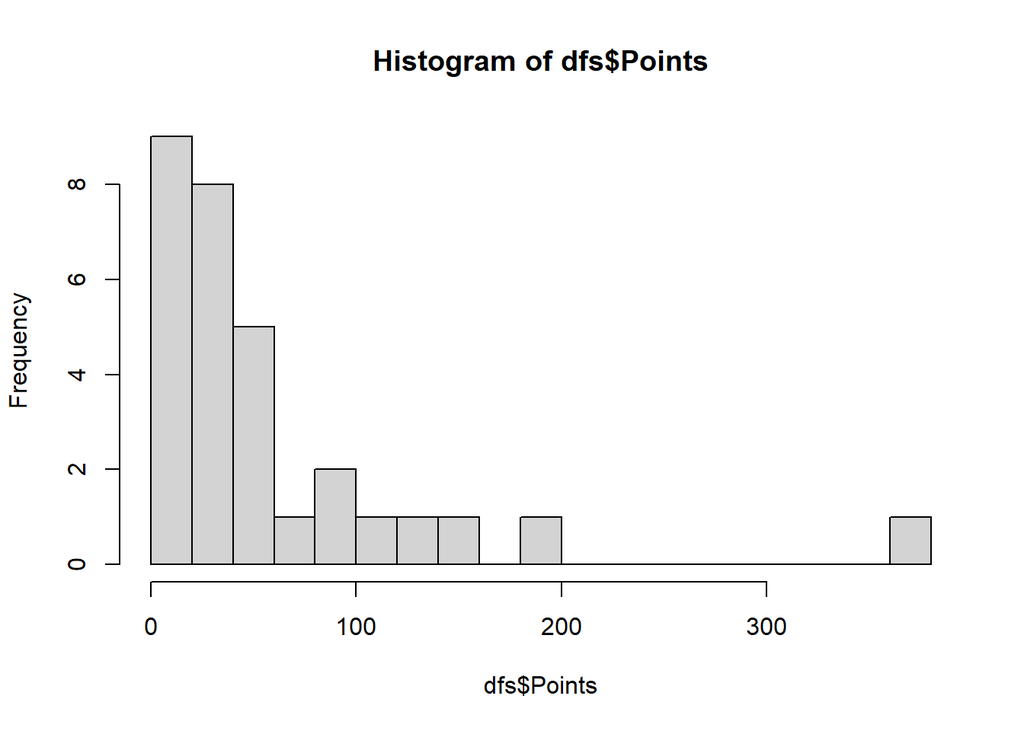

```r
hist(dfs$Points, breaks = 20)
```

Looks like a positive skew.

Now lets see a representation of what our data looks like vs what it could look like perfectly normally distributed.

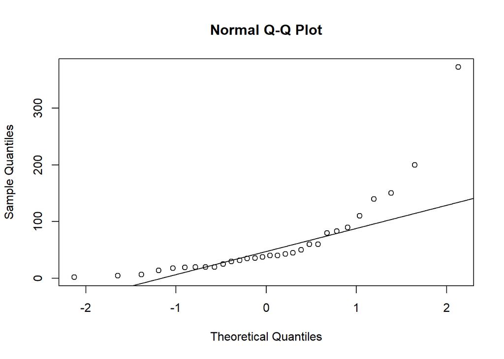

```r
{qqnorm(dfs$Points)
qqline(dfs$Points)}
```

In this plot, our data is represented by the dots, with the solid line being drawn between the 1st and 3rd quartile. It is a solid comparison of our numbers and a truly normal set of numbers. The dots that stray from the line represent a stray away from normalcy (a stray away from a bell curve).

I would think that our career earnings would follow this pattern as well considering the first place horse gets the most points per race as well as the most money, with both decreasing the worse they do in the race. Let’s see if this is true.

```r
summary(dfs$Career.Earnings.)
```

```
##    Min. 1st Qu.  Median    Mean 3rd Qu.    Max.
##   63000  193400  333675  524281  461080 2871200
```

And again we have a very wide range of $2,808,200 with our Min most likely sitting in a bottle of Elmer’s glue by now.

Standard deviation now

```r
sd(dfs$Career.Earnings.)
```

```
## [1] 666761.6
```

Our ranges of 1 standard deviation from the mean

```r
mean(dfs$Career.Earnings.)-sd(dfs$Career.Earnings.)
```

```
## [1] -142480.7
```

```r
mean(dfs$Career.Earnings.)+sd(dfs$Career.Earnings.)
```

```
## [1] 1191043
```

Now the percentages of our horses withing 1, 2, and 3 standard deviations of our mean.

```r
sd_range_earnings <- dfs$Career.Earnings.
sd_range_earnings <- sd_range_earnings[!(sd_range_earnings>mean(dfs$Career.Earnings.)+sd(dfs$Career.Earnings.))]
length(sd_range_earnings)/length(dfs$Career.Earnings.)
```

```
## [1] 0.8666667
```

```r
sd_range_earnings2 <- dfs$Career.Earnings.
sde2 <- sd(dfs$Career.Earnings.)*2
sd_range_earnings2 <- sd_range_earnings2[!(sd_range_earnings2>mean(dfs$Career.Earnings.)+sde2)]
length(sd_range_earnings2)/length(dfs$Career.Earnings.)
```

```
## [1] 0.9333333
```

```r
sd_range_earnings3 <- dfs$Career.Earnings.
sde3 <- sd(dfs$Career.Earnings.)*3
sd_range_earnings3 <- sd_range_earnings3[!(sd_range_earnings3>mean(dfs$Career.Earnings.)+sde3)]
length(sd_range_earnings3)/length(dfs$Career.Earnings.)
```

```
## [1] 0.9333333
```

This is looking pretty familiar so far.

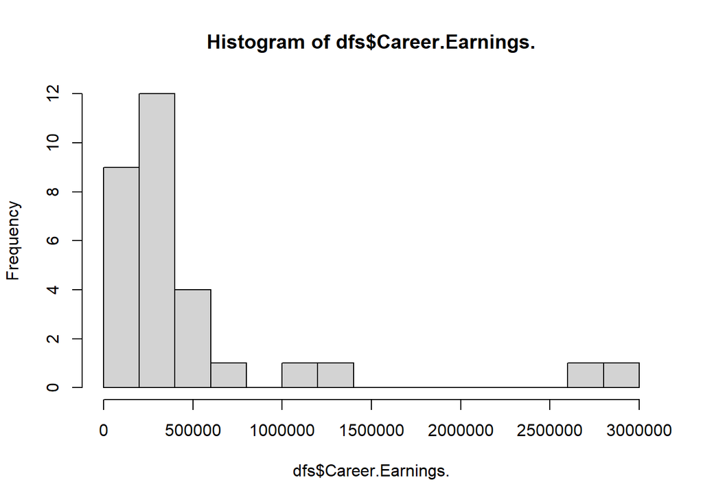

```r
hist(dfs$Career.Earnings., breaks = 20)
```

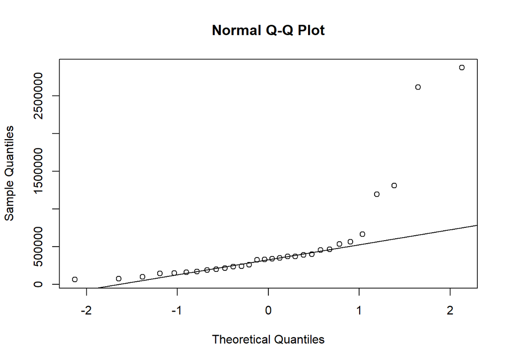

```r
{qqnorm(dfs$Career.Earnings.)
qqline(dfs$Career.Earnings.)}
```

This set of numbers seems to have an even more normalized distribution withing the 50% between the 1st and 3rd quartile. We would have somewhat of a bell curve (maybe with a slight right skew) in our histograms if it wasn’t for those 4 positive outliars.

For our two way lets plot our Points and Career Earnings against each other. If we see a straight line it means they have the same distribution.

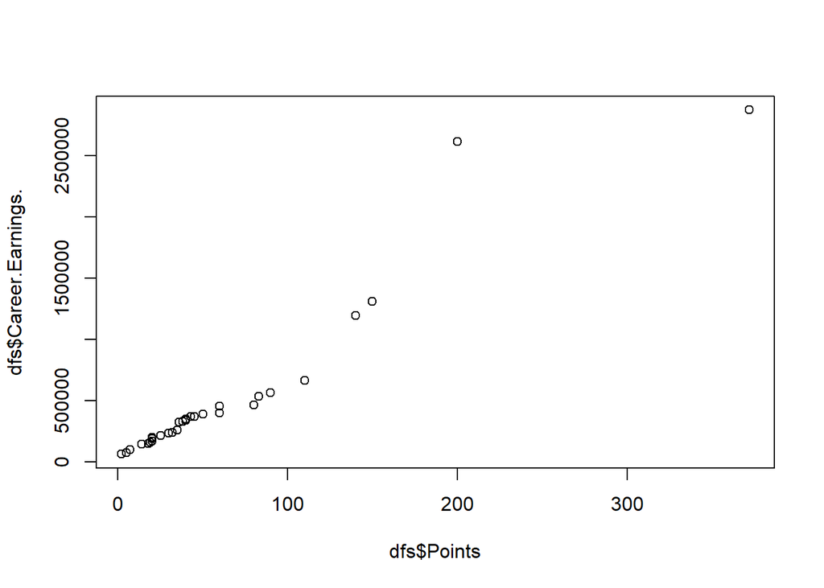

```r
qqplot(dfs$Points,dfs$Career.Earnings.)
```

Once again we would have a pretty graph if it wasn’t for our outliars.

Lets look at our data in another kind of plot. It will give us a visual of just how far out our outliars are.

First the Points

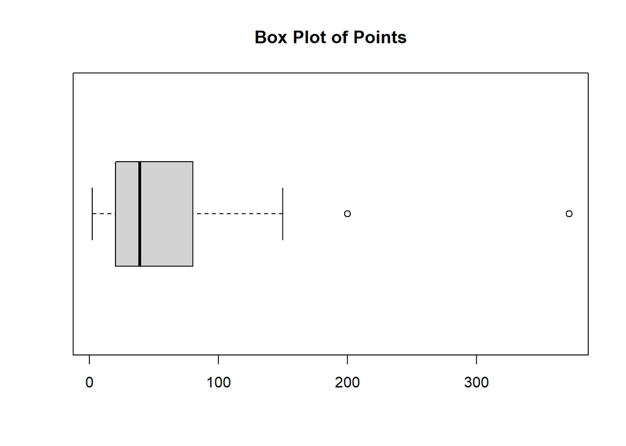

```r
boxplot(dfs$Points, horizontal = TRUE, main = "Box Plot of Points")
```

Now the Career Earnings

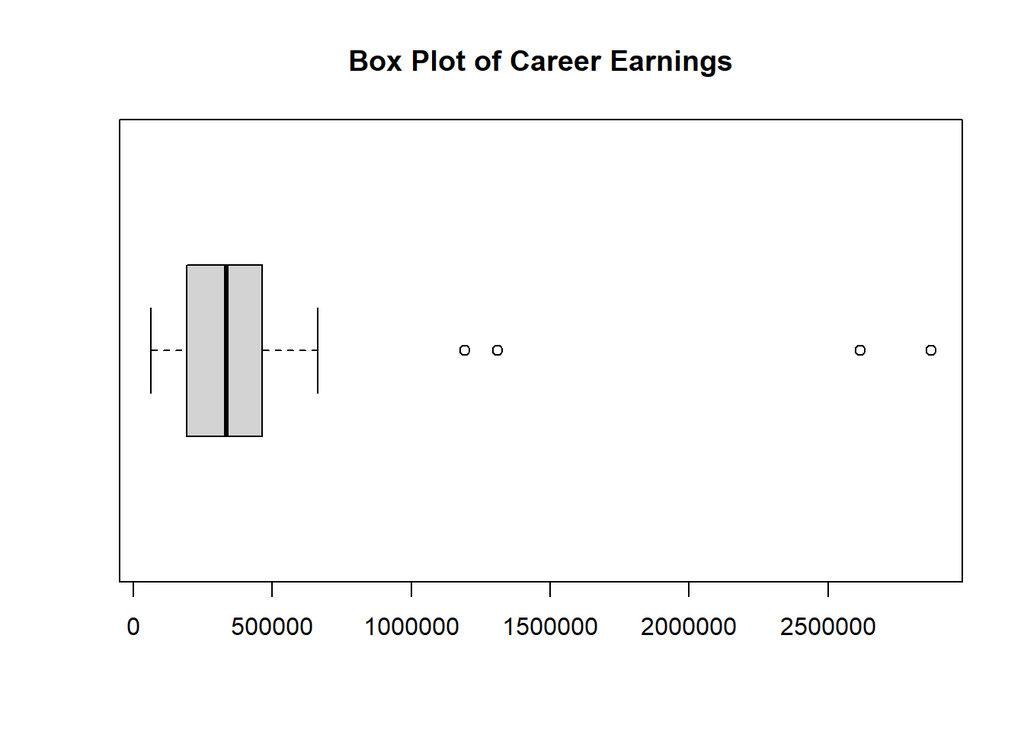

```r
boxplot(dfs$Career.Earnings., horizontal = TRUE, main = "Box Plot of Career Earnings")
```

So it seems in our points we have only 2 far outliars, while in our Career earnings we have 4. 2 being far and 2 mid range. I suspect this is caused by the difference in payout of each race. First through fourth is assigned the same amount of points each race, but the monetary rewards vary. Despite this small difference there seems to be a correlation between points and career earnings.

I want to quantify the correlation between these two variables. I should be able to use the Pearson correlation formula (Thank God for built in functions) because both variables are considered to be ratio.

```r
cor(dfs$Points,dfs$Career.Earnings., method = c("pearson"))
```

```
## [1] 0.7905361
```

So in this formula an output of “1” represents a perfect positive linear correlation, “-1” a perfect negative linear correlation, and “0” represents no correlation at all. Our output tells us there is a pretty good positive correlation! Of course we already knew that but it’s cool to put a number to it.

I think by now we have a good understanding of our quantitative variables. We see that our two variables are not perfectly correlated because of the difference in race rewards, but they are still very highly correlated.

## Project Part 4

### Hypothesis Testing

For my First hypothesis I would like to continue along a topic I mentioned earlier. I want to see how Bob Baffert ranks among the other trainers in the top 30 for the season. I will do a simple test to see if Bob Baffert is as good as the other trainers by comparing his mean to the overall mean of $524,281.

$$H_0:\quad \mu_{Baffert Earnings}=524281\\
H_a:\quad \mu_{Baffert Earnings}\neq524281$$

For my second hypothesis I will compare the frequency of Bob baffert in our table to what you would normally expect for a trainer in the season’s top 30. A normal expectation would be for each name to have a relative frequency of 1/30.

$$H_0:\quad {N_{Bob Baffert}={1\over{30}}}\\
H_a:\quad {N_{Bob Baffert}\neq{1\over{30}}}$$
Let’s see if Bob Baffert really is as great as we thing he is or if it’s just that when you train more horses you increase the odds of having your name written by a winner.